# HW2 Alvaro Martin

Alvaro Martin 196 100475318

## Explanation of the dataset

Heart failure is a common event caused by CVDs (cardio vascular diseases) and this dataset contains 11 features that can be used to predict a possible heart disease. We also want to find the most important variables affecting our variable of interest.

Data set contains the following information:

1. Age: age of the patient [years]
2. Sex: sex of the patient [M: Male, F: Female]
3. ChestPainType: chest pain type [TA: Typical Angina, ATA: Atypical Angina, NAP: Non-Anginal Pain, ASY: Asymptomatic]
4. RestingBP: resting blood pressure [mm Hg]
5. Cholesterol: serum cholesterol [mm/dl]
6. FastingBS: fasting blood sugar [1: if FastingBS > 120 mg/dl, 0:otherwise]
7. RestingECG: resting electrocardiogram results [Normal: Normal, ST: having ST-T wave abnormality (T wave inversions and/or ST elevation or depression of > 0.05 mV), LVH: showing probable or definite left ventricular hypertrophy by Estes’ criteria]
8. MaxHR: maximum heart rate achieved [Numeric value between 60 and 202]
9. ExerciseAngina: exercise-induced angina [Y: Yes, N: No]
10. Oldpeak: oldpeak = ST [Numeric value measured in depression]
11. ST_Slope: the slope of the peak exercise ST segment [Up: upsloping, Flat: flat, Down: downsloping]
12. HeartDisease: output class [1: heart disease, 0: Normal]

*GOAL:* Our goal is to predict HeartDisease (classification) and a numeric variable that we will create to meassure the patient helthiness (regression) with the information of the rest of the variables.

First of all, let’s load the data and the libraries needed.

```r
library(GGally)
```

```r
library(ggplot2)
library(caret)
if (!require("ggridges")){
  install.packages("ggridges")
}
library(ggridges)
if (!require("viridis")){
  install.packages("viridis")
}
library(viridis)
if (!require("hrbrthemes")){
  install.packages("hrbrthemes")
}
```

```
## NOTE: Either Arial Narrow or Roboto Condensed fonts are required to use these themes.
```

```
##       Please use hrbrthemes::import_roboto_condensed() to install Roboto Condensed and
```

```
##       if Arial Narrow is not on your system, please see https://bit.ly/arialnarrow
```

```r
library(hrbrthemes)
if (!require("ggExtra")){
  install.packages("ggExtra")
}
library(ggExtra)
if (!require("gridExtra")){
  install.packages('gridExtra')
}
library(gridExtra)

library(mice)
library(VIM)
library(Amelia)
library(RANN)
library(caTools)
library(glmnet)
library(pROC)
```

```r
library(rpart)
library(rpart.plot)
library(randomForest)
library(olsrr)
set.seed(123)
rm(list=ls())
heart_data = read.csv('heart.csv')
```

Let’s have a look at the data and see what are the different variables:

```r
head(heart_data)
```

|  | Age | Sex | ChestPainType | RestingBP | Cholesterol | FastingBS | RestingECG | MaxHR | ExerciseAngina | Oldpeak | ST_Slope | HeartDisease |
| --- | --- | --- | --- | --- | --- | --- | --- | --- | --- | --- | --- | --- |
| 1 | 40 | M | ATA | 140 | 289 | 0 | Normal | 172 | N | 0.0 | Up | 0 |
| 2 | 49 | F | NAP | 160 | 180 | 0 | Normal | 156 | N | 1.0 | Flat | 1 |
| 3 | 37 | M | ATA | 130 | 283 | 0 | ST | 98 | N | 0.0 | Up | 0 |
| 4 | 48 | F | ASY | 138 | 214 | 0 | Normal | 108 | Y | 1.5 | Flat | 1 |
| 5 | NA | M | NAP | 150 | 195 | 0 | Normal | 122 | N | 0.0 | Up | 0 |
| 6 | 39 | M | NAP | 120 | 339 | 0 | Normal | 170 | N | 0.0 | Up | 0 |

```r
str(heart_data)
```

```
## 'data.frame':    918 obs. of  12 variables:
##  $ Age           : int  40 49 37 48 NA 39 45 54 37 48 ...
##  $ Sex           : chr  "M" "F" "M" "F" ...
##  $ ChestPainType : chr  "ATA" "NAP" "ATA" "ASY" ...
##  $ RestingBP     : int  140 160 130 138 150 120 130 110 140 120 ...
##  $ Cholesterol   : int  289 180 283 214 195 339 237 208 207 284 ...
##  $ FastingBS     : int  0 0 0 0 0 0 0 0 0 0 ...
##  $ RestingECG    : chr  "Normal" "Normal" "ST" "Normal" ...
##  $ MaxHR         : int  172 156 98 108 122 170 170 142 130 120 ...
##  $ ExerciseAngina: chr  "N" "N" "N" "Y" ...
##  $ Oldpeak       : num  0 1 0 1.5 0 0 0 0 1.5 0 ...
##  $ ST_Slope      : chr  "Up" "Flat" "Up" "Flat" ...
##  $ HeartDisease  : int  0 1 0 1 0 0 0 0 1 0 ...
```

```r
summary(heart_data)
```

```
##       Age            Sex            ChestPainType        RestingBP
##  Min.   :28.00   Length:918         Length:918         Min.   :  0.0
##  1st Qu.:47.00   Class :character   Class :character   1st Qu.:120.0
##  Median :54.00   Mode  :character   Mode  :character   Median :130.0
##  Mean   :53.51                                         Mean   :132.4
##  3rd Qu.:60.00                                         3rd Qu.:140.0
##  Max.   :77.00                                         Max.   :200.0
##  NA's   :1                                             NA's   :1
##   Cholesterol      FastingBS       RestingECG            MaxHR
##  Min.   :  0.0   Min.   :0.0000   Length:918         Min.   : 60.0
##  1st Qu.:173.0   1st Qu.:0.0000   Class :character   1st Qu.:120.0
##  Median :223.0   Median :0.0000   Mode  :character   Median :138.0
##  Mean   :198.8   Mean   :0.2331                      Mean   :136.8
##  3rd Qu.:267.0   3rd Qu.:0.0000                      3rd Qu.:156.0
##  Max.   :603.0   Max.   :1.0000                      Max.   :202.0
##  NA's   :1                                           NA's   :1
##  ExerciseAngina        Oldpeak          ST_Slope          HeartDisease
##  Length:918         Min.   :-2.6000   Length:918         Min.   :0.0000
##  Class :character   1st Qu.: 0.0000   Class :character   1st Qu.:0.0000
##  Mode  :character   Median : 0.6000   Mode  :character   Median :1.0000
##                     Mean   : 0.8874                      Mean   :0.5534
##                     3rd Qu.: 1.5000                      3rd Qu.:1.0000
##                     Max.   : 6.2000                      Max.   :1.0000
##
```

## Preprocessing and visualization

As we saw that we have some categorical variables, let’s convert them into factors

```r
heart_data$Sex = as.factor(heart_data$Sex)
heart_data$ChestPainType = as.factor(heart_data$ChestPainType)
heart_data$FastingBS=factor(heart_data$FastingBS,levels=c(1,0))
heart_data$ExerciseAngina = as.factor(heart_data$ExerciseAngina)
heart_data$ST_Slope = as.factor(heart_data$ST_Slope)
heart_data$HeartDisease = factor(heart_data$HeartDisease,labels=c("Disease","Not_disease"),levels=c(1,0))
heart_data$RestingECG = as.factor(heart_data$RestingECG)
```

Now let’s move to the numerical variables. How are they related?

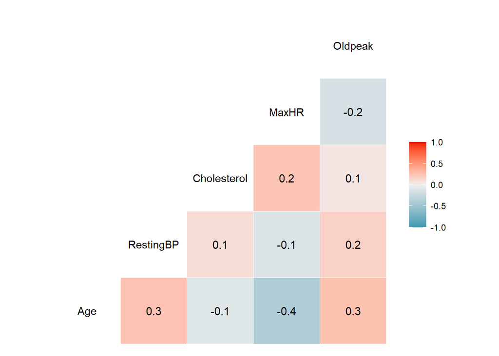

```r
library(GGally)
ggcorr(heart_data, label = T)
```

```r
# It is not our case, but in the case that some of our variables were highly correlated, it would be a good idea to do PCA to reduce the dimensionality of our dataset
```

**OUTLIERS**

We only have to care about the continuous variabes, that are the one which may have outliers in this case

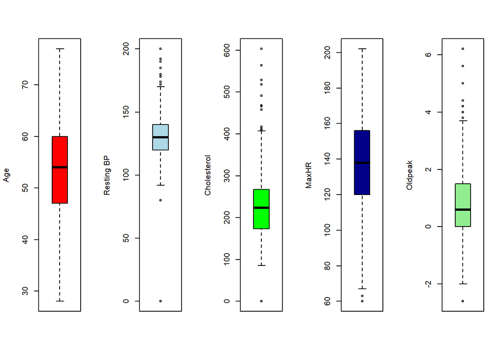

```r
# Let's identify the outliers
par(mfrow=c(1,5)) # 5 figures arranged in 1 row and 5 columns
boxplot(heart_data$Age,ylab = "Age", col='red')
boxplot(heart_data$RestingBP, ylab = "Resting BP", col = 'lightblue')
# We have outliers
boxplot(heart_data$Cholesterol,ylab = "Cholesterol", col = 'green')
# Outliers
boxplot(heart_data$MaxHR,ylab = "MaxHR", col = 'darkblue')
# A few outliers
boxplot(heart_data$Oldpeak,ylab = "Oldpeak", col ='lightgreen')
```

```r
# Outliers
```

```r
# Identification by IQR:
QI <- quantile(heart_data$Age, 0.25, na.rm = TRUE)
QS <- quantile(heart_data$Age, 0.75, na.rm = TRUE)
IQR = QS-QI

sum(heart_data$Age < QI - 1.5*IQR | heart_data$Age > QS + 1.5*IQR, na.rm = TRUE)
```

```
## [1] 0
```

```r
# No outliers in variable Age

QI <- quantile(heart_data$RestingBP, 0.25, na.rm = TRUE)
QS <- quantile(heart_data$RestingBP, 0.75, na.rm = TRUE)
IQR = QS-QI

sum(heart_data$RestingBP < QI - 1.5*IQR | heart_data$RestingBP > QS + 1.5*IQR, na.rm = TRUE)
```

```
## [1] 28
```

```r
# 28 outliers

QI <- quantile(heart_data$Cholesterol, 0.25, na.rm = TRUE)
QS <- quantile(heart_data$Cholesterol, 0.75, na.rm = TRUE)
IQR = QS-QI

sum(heart_data$Cholesterol < QI - 1.5*IQR | heart_data$Cholesterol > QS + 1.5*IQR, na.rm = TRUE)
```

```
## [1] 183
```

```r
# 183 outliers. That is a lot. Later we will have a look at this variable to see what is happening to have so many outliers.

QI <- quantile(heart_data$MaxHR, 0.25, na.rm = TRUE)
QS <- quantile(heart_data$MaxHR, 0.75, na.rm = TRUE)
IQR = QS-QI

sum(heart_data$MaxHR < QI - 1.5*IQR | heart_data$MaxHR > QS + 1.5*IQR, na.rm = TRUE)
```

```
## [1] 2
```

```r
# 2 outliers

QI <- quantile(heart_data$Oldpeak, 0.25, na.rm = TRUE)
QS <- quantile(heart_data$Oldpeak, 0.75, na.rm = TRUE)
IQR = QS-QI

sum(heart_data$Oldpeak < QI - 1.5*IQR | heart_data$Oldpeak > QS + 1.5*IQR, na.rm = TRUE)
```

```
## [1] 16
```

```r
# 16 outliers

# Before we decide what to do with the outliers, let's try another methods
# to identify them and see if we get similar results as the ones obatined.

# Identification by the 3-sigma rule:
mu <- mean(heart_data$Age, na.rm = TRUE)
sigma <- sd(heart_data$Age, na.rm = TRUE)
sum(heart_data$Age < mu - 3*sigma | heart_data$Age > mu + 3*sigma, na.rm = TRUE)
```

```
## [1] 0
```

```r
# No outliers in Age

mu <- mean(heart_data$RestingBP,na.rm = TRUE)
sigma <- sd(heart_data$RestingBP, na.rm = TRUE)
sum(heart_data$RestingBP < mu - 3*sigma | heart_data$RestingBP > mu + 3*sigma, na.rm = TRUE)
```

```
## [1] 8
```

```r
# 8 outliers.

mu <- mean(heart_data$Cholesterol,na.rm = TRUE)
sigma <- sd(heart_data$Cholesterol,na.rm = TRUE)
sum(heart_data$Cholesterol < mu - 3*sigma | heart_data$Cholesterol > mu + 3*sigma, na.rm = TRUE )
```

```
## [1] 3
```

```r
# 3 otuliers

which(heart_data$Cholesterol > mu + 3*sigma)
```

```
## [1]  77 150 617
```

```r
heart_data$Cholesterol[77]
```

```
## [1] 529
```

```r
heart_data$Cholesterol[150]
```

```
## [1] 603
```

```r
heart_data$Cholesterol[617]
```

```
## [1] 564
```

```r
# Although this are extreme values, it is possible to have
# cholesterol at this levels:
# https://www.clinicbarcelona.org/asistencia/enfermedades/hipercolesterolemia/evolucion-de-la-enfermedad

mu <- mean(heart_data$MaxHR,  na.rm = TRUE)
sigma <- sd(heart_data$MaxHR,  na.rm = TRUE)
sum(heart_data$MaxHR < mu - 3*sigma | heart_data$MaxHR > mu + 3*sigma, na.rm = TRUE)
```

```
## [1] 1
```

```r
# 1 outlier

mu <- mean(heart_data$Oldpeak,  na.rm = TRUE)
sigma <- sd(heart_data$Oldpeak,  na.rm = TRUE)
sum(heart_data$Oldpeak < mu - 3*sigma | heart_data$Oldpeak > mu + 3*sigma,  na.rm = TRUE)
```

```
## [1] 7
```

```r
# 7 outliers

# With the 3 sigma identification method we have detected less outliers.
```

It always depends on the context to decide what to do with the outliers. Are they observations that we need to take into account? Do we have to remove the outliers? Are they ‘absurd’ observations?

Let’s see it now with the help of other graphs, visualizing the variables can help us to understand the variables better and see if the extreme values make sense or not.

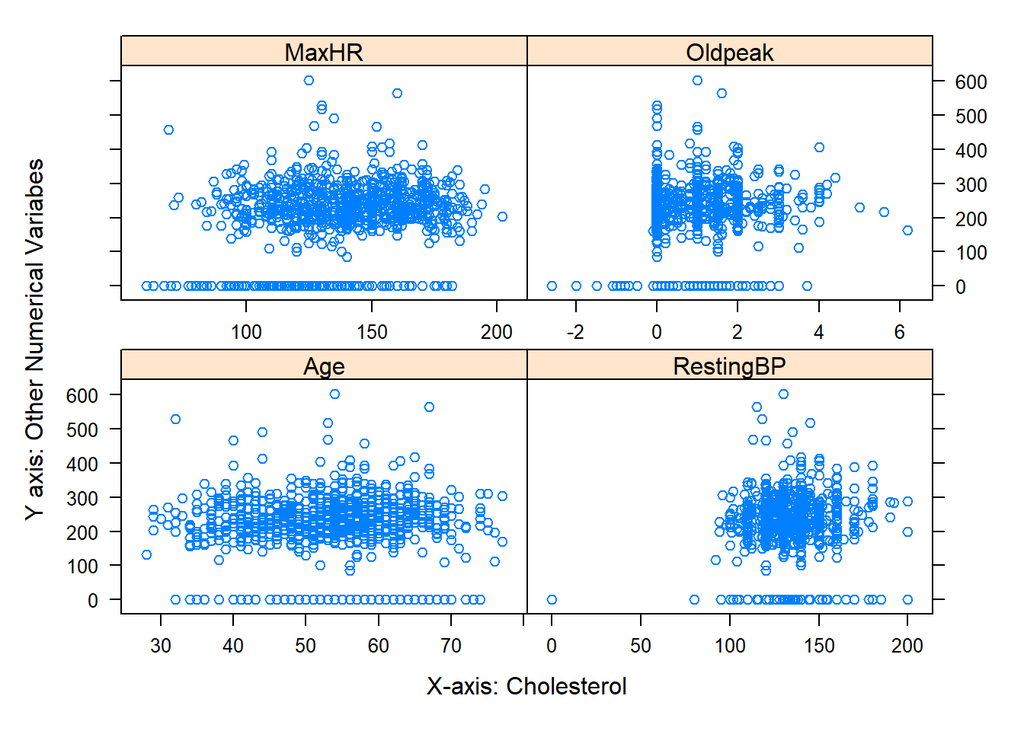

```r
# Scatter plot of our numerical variables:
featurePlot(x = heart_data[, c(1,4,8,10)], y = heart_data$Cholesterol,
            plot = "scatter", layout = c(2, 2), labels = c("X-axis: Cholesterol", "Y axis: Other Numerical Variabes"))
```

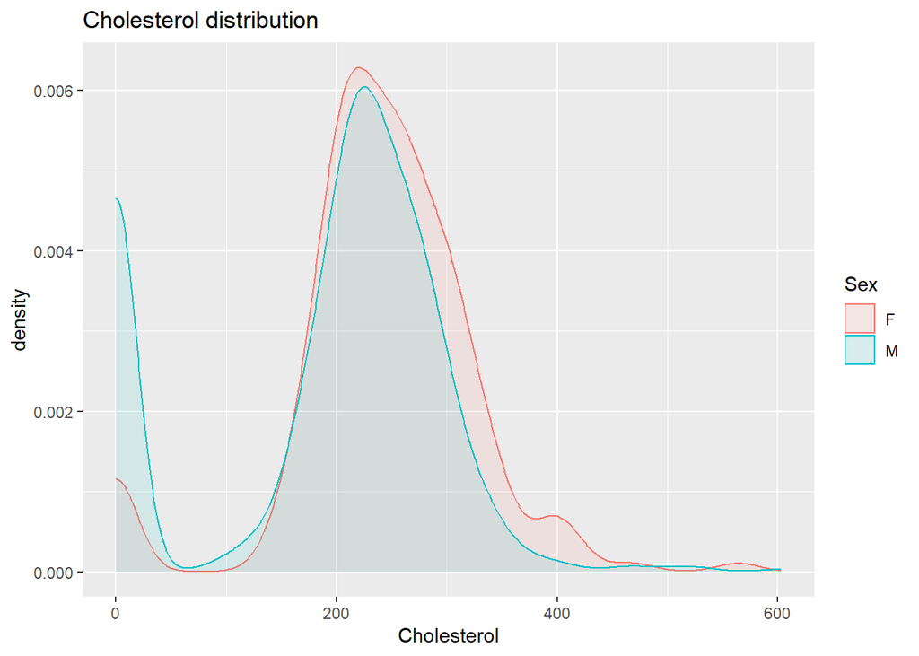

```r
# We see that there are some values with cholesterol 0, let's have a deeper look
ggplot(heart_data, aes(Cholesterol, na.rm =TRUE)) +
  geom_density(aes(group=Sex, colour=Sex, fill=Sex), alpha=0.1) +
  ggtitle("Cholesterol distribution")
```

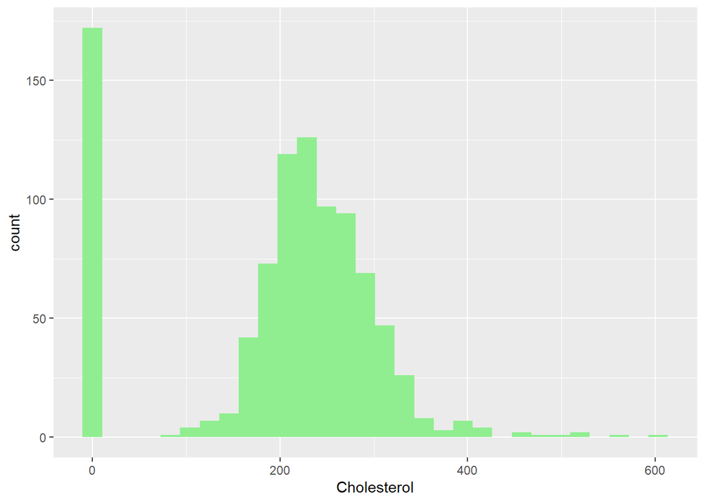

```r
ggplot(heart_data)+aes(Cholesterol)+geom_histogram(bins = 30,fill = 'lightgreen')
```

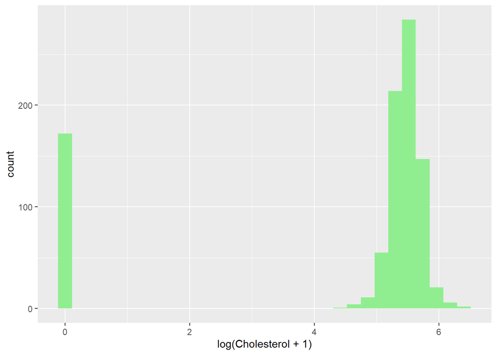

```r
# Let's use a logarithmic scale to see clearer the gap
ggplot(heart_data)+aes(log(Cholesterol+1))+geom_histogram(bins = 30,fill = 'lightgreen')
```

```r
heart_data$Cholesterol[heart_data$Cholesterol==0] <- NA
```

Let’s continue with the rest of the variables

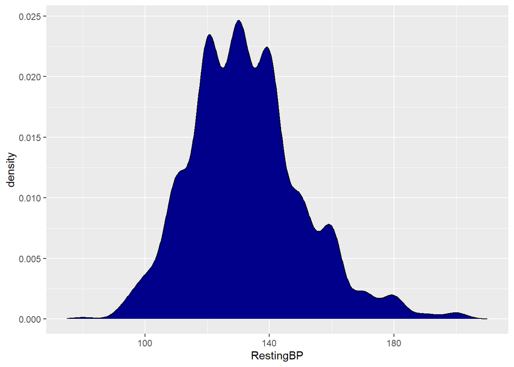

```r
ggplot(heart_data, aes(RestingBP))+xlim(c(75,210)) + geom_density(fill="darkblue")
```

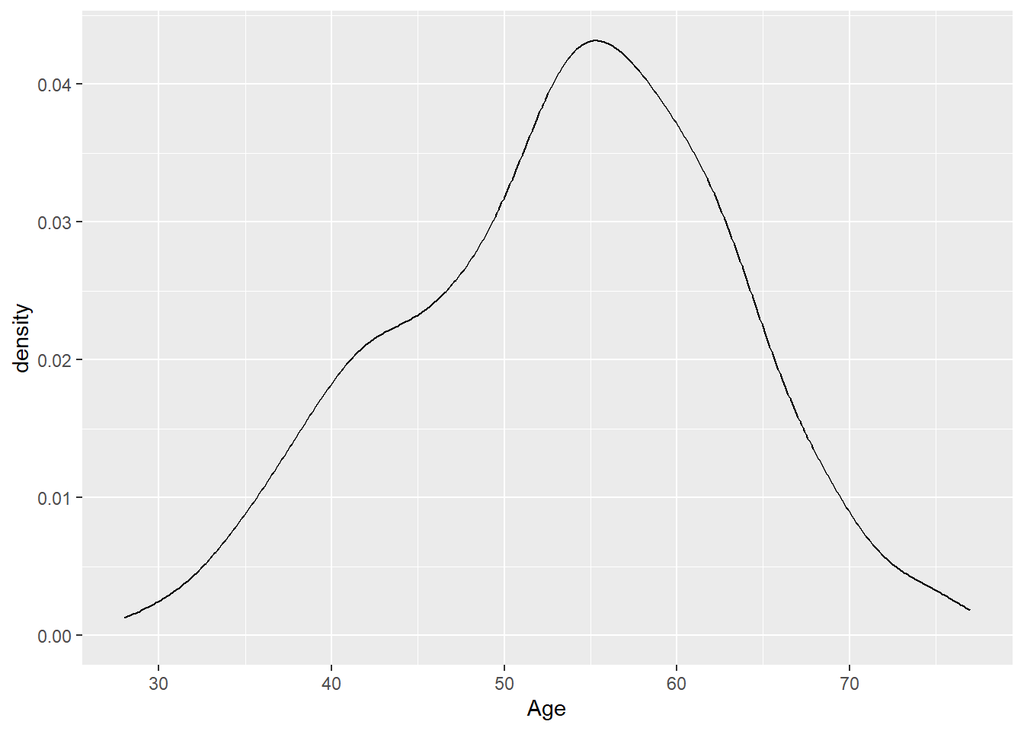

```r
# The distribution is fine and the values make sense.

# Age:
ggplot(heart_data)+aes(x=Age)+geom_density()
```

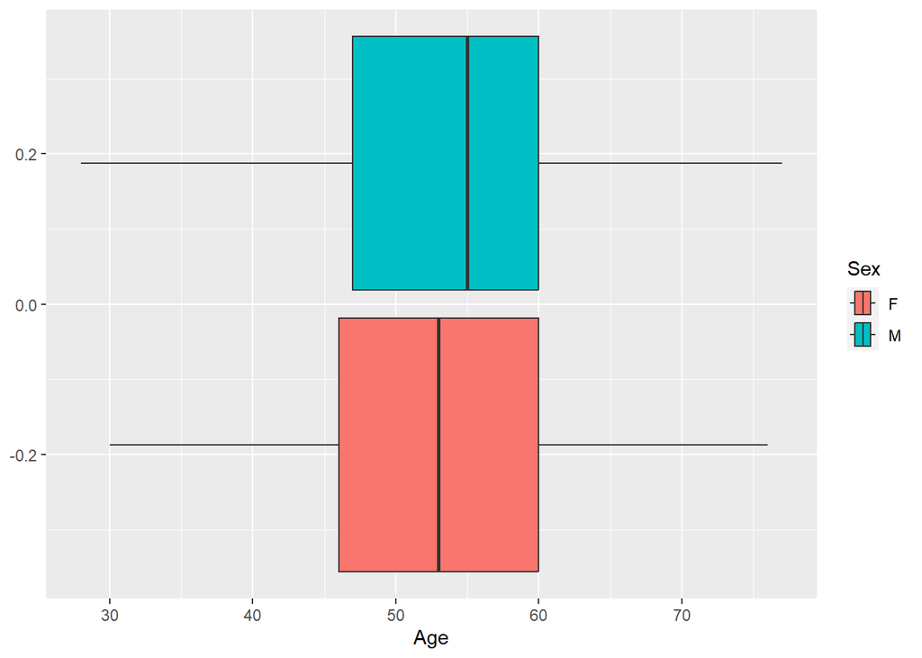

```r
ggplot(heart_data)+aes(Age, fill = Sex)+geom_boxplot()
```

```r
# Age values are ok, we don't see anything extreme such as people of 120 years that we might think it is a wrong data.
```

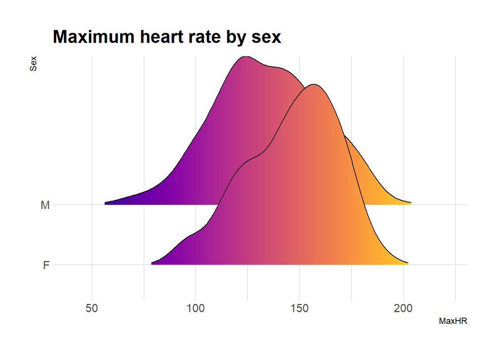

```r
# Let's continue with the maximum heart rate
ggplot(heart_data, aes(x = MaxHR, y = Sex, fill = ..x..)) +
  geom_density_ridges_gradient(scale = 3, rel_min_height = 0.01) +
  scale_fill_viridis(name = "Temp. [F]", option = "C") +
  labs(title = 'Maximum heart rate by sex') +
  theme_ipsum() +
  theme(
    legend.position="none",
    panel.spacing = unit(0.1, "lines"),
    strip.text.x = element_text(size = 8)
  )
```

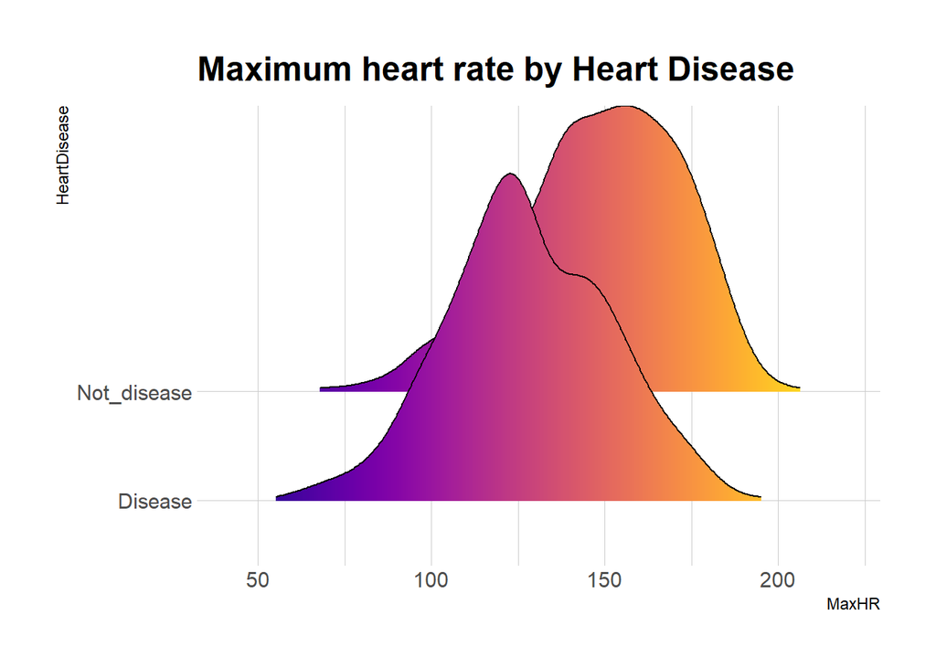

```r
# Against our variable of interest:
ggplot(heart_data, aes(x = MaxHR, y = HeartDisease, fill = ..x..)) +
  geom_density_ridges_gradient(scale = 3, rel_min_height = 0.01) +
  scale_fill_viridis(name = "Temp. [F]", option = "C") +
  labs(title = 'Maximum heart rate by Heart Disease') +
  theme_ipsum() +
  theme(
    legend.position="none",
    panel.spacing = unit(0.1, "lines"),
    strip.text.x = element_text(size = 8)
  )
```

```r
# SO far, we don't see any outlier or any value that does not make sense.
# We can start seeing some interesting relations, for example, from the last graph we may think that people with a lower maximum Heart Rate are more probable to have the disease.
```

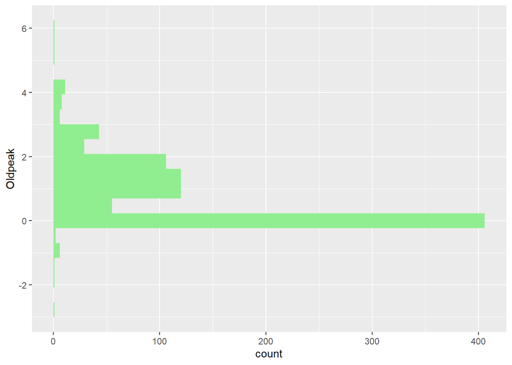

```r
# Distribution of oldpeak variable
ggplot(heart_data)+aes(y= Oldpeak)+geom_histogram(bins = 20, fill = 'lightgreen')
```

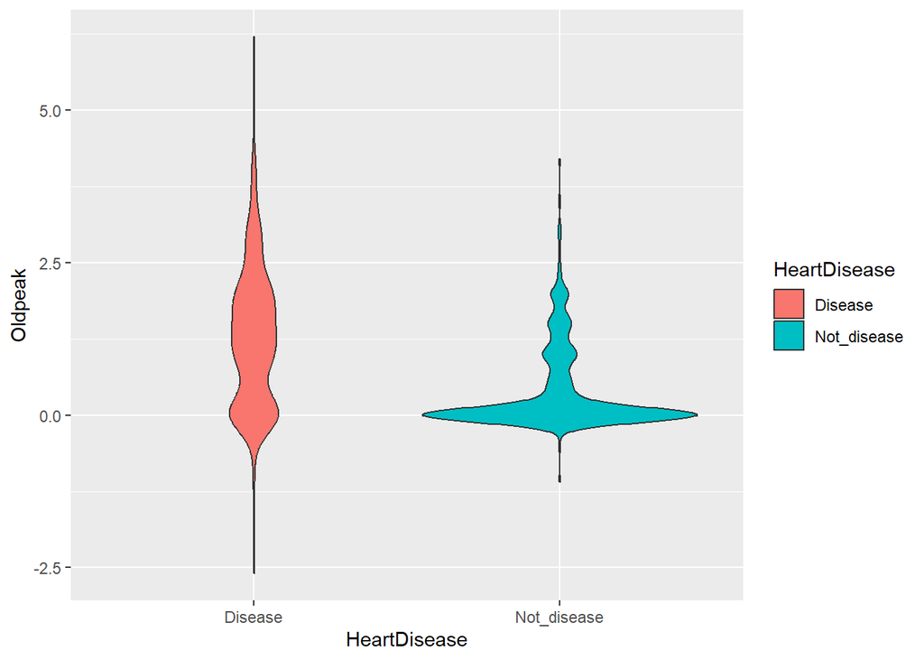

```r
ggplot(heart_data, aes(x = HeartDisease, y=Oldpeak, fill = HeartDisease)) + # fill=name allow to automatically dedicate a color for each group
  geom_violin()
```

Finally, I don’t see any ‘strange’ value here, therefore I won’t remove the outliers of this variable.

In the end, I decided to leave the majority of the outliers. This is because I consider that they represent natural variations in the population (I also don’t have many outliers, so we don’t have a very noisy dataset neither).

I decided to removed onnly the *Cholesterol=0* outliers because they represent measurement errors.

**MISSING VALUES**

```r
# MISSING VALUES:
# How many missing values we have?
length(which(is.na(heart_data)))
```

```
## [1] 176
```

```r
# Almost all the missing values that I have are the ones that
# we have seen on the cholesterol:
colSums(is.na(heart_data))
```

```
##            Age            Sex  ChestPainType      RestingBP    Cholesterol
##              1              0              0              1            173
##      FastingBS     RestingECG          MaxHR ExerciseAngina        Oldpeak
##              0              0              1              0              0
##       ST_Slope   HeartDisease
##              0              0
```

```r
# As I have few missing values in the rest of the variables, I am going to add some more in order to complicate a bit more the preprocessing.
for(i in 1:(ncol(heart_data)-1)){  # I don't want missing values on the dependent variable
  for(j in 1:nrow(heart_data)){
   if((i+j)%%100==0){  # Add an NA every 100 observations
     heart_data[j,i]<-NA
   }
  }
}

# What is now the percentage of NAs in our data?
sum(is.na(heart_data))/(nrow(heart_data)*ncol(heart_data))*100
```

```
## [1] 2.478214
```

```r
# 2.48% of missing values

# Where are the NAs?
for(i in 1:ncol(heart_data)){
  if(any(is.na(heart_data[,i]))){
    cat("Variable ",names(heart_data)[i]," has NA values\n")
  }
}
```

```
## Variable  Age  has NA values
## Variable  Sex  has NA values
## Variable  ChestPainType  has NA values
## Variable  RestingBP  has NA values
## Variable  Cholesterol  has NA values
## Variable  FastingBS  has NA values
## Variable  RestingECG  has NA values
## Variable  MaxHR  has NA values
## Variable  ExerciseAngina  has NA values
## Variable  Oldpeak  has NA values
## Variable  ST_Slope  has NA values
```

```r
# Now we have mising values in all the variables.
```

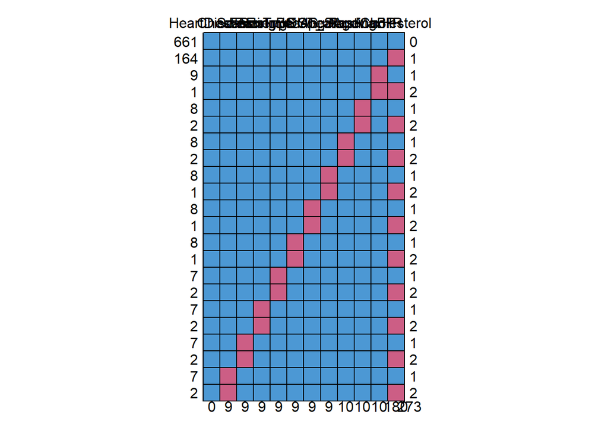

```
##     HeartDisease Sex ChestPainType FastingBS RestingECG ExerciseAngina Oldpeak
## 661            1   1             1         1          1              1       1
## 164            1   1             1         1          1              1       1
## 9              1   1             1         1          1              1       1
## 1              1   1             1         1          1              1       1
## 8              1   1             1         1          1              1       1
## 2              1   1             1         1          1              1       1
## 8              1   1             1         1          1              1       1
## 2              1   1             1         1          1              1       1
## 8              1   1             1         1          1              1       1
## 1              1   1             1         1          1              1       1
## 8              1   1             1         1          1              1       0
## 1              1   1             1         1          1              1       0
## 8              1   1             1         1          1              0       1
## 1              1   1             1         1          1              0       1
```

[output cut: 33 more lines]

```r
# 3 different ways to visualize where are the NAs
md.pattern(heart_data)
```

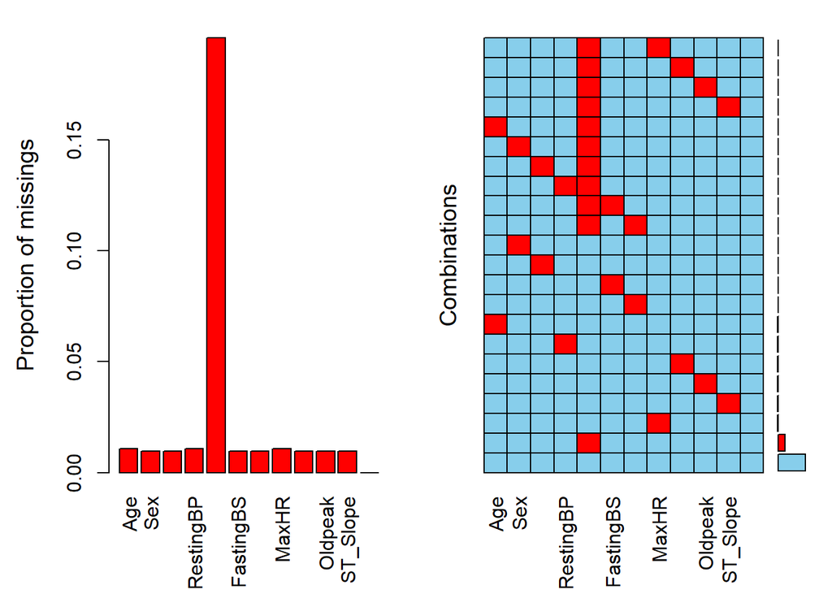

```
##
##  Missings per variable:
##        Variable Count
##             Age    10
##             Sex     9
##   ChestPainType     9
##       RestingBP    10
##     Cholesterol   180
##       FastingBS     9
##      RestingECG     9
##           MaxHR    10
##  ExerciseAngina     9
##         Oldpeak     9
##        ST_Slope     9
##    HeartDisease     0
##
##  Missings in combinations of variables:
##             Combinations Count    Percent
##  0:0:0:0:0:0:0:0:0:0:0:0   661 72.0043573
##  0:0:0:0:0:0:0:0:0:0:1:0     8  0.8714597
##  0:0:0:0:0:0:0:0:0:1:0:0     8  0.8714597
##  0:0:0:0:0:0:0:0:1:0:0:0     8  0.8714597
##  0:0:0:0:0:0:0:1:0:0:0:0     9  0.9803922
##  0:0:0:0:0:0:1:0:0:0:0:0     7  0.7625272
##  0:0:0:0:0:1:0:0:0:0:0:0     7  0.7625272
##  0:0:0:0:1:0:0:0:0:0:0:0   164 17.8649237
##  0:0:0:0:1:0:0:0:0:0:1:0     1  0.1089325
##  0:0:0:0:1:0:0:0:0:1:0:0     1  0.1089325
##  0:0:0:0:1:0:0:0:1:0:0:0     1  0.1089325
##  0:0:0:0:1:0:0:1:0:0:0:0     1  0.1089325
##  0:0:0:0:1:0:1:0:0:0:0:0     2  0.2178649
##  0:0:0:0:1:1:0:0:0:0:0:0     2  0.2178649
##  0:0:0:1:0:0:0:0:0:0:0:0     8  0.8714597
##  0:0:0:1:1:0:0:0:0:0:0:0     2  0.2178649
##  0:0:1:0:0:0:0:0:0:0:0:0     7  0.7625272
##  0:0:1:0:1:0:0:0:0:0:0:0     2  0.2178649
##  0:1:0:0:0:0:0:0:0:0:0:0     7  0.7625272
##  0:1:0:0:1:0:0:0:0:0:0:0     2  0.2178649
##  1:0:0:0:0:0:0:0:0:0:0:0     8  0.8714597
##  1:0:0:0:1:0:0:0:0:0:0:0     2  0.2178649
```

```r
# We see what we can expect, the majority of the observation with NA have
# the missing value on the cholesterol variable, and the rest of NAs
# are distributed in the rest of the variables.

# Now we are going to see more in detail how the missing values are
# distributed in our dataset:
summary(aggr(heart_data))
```

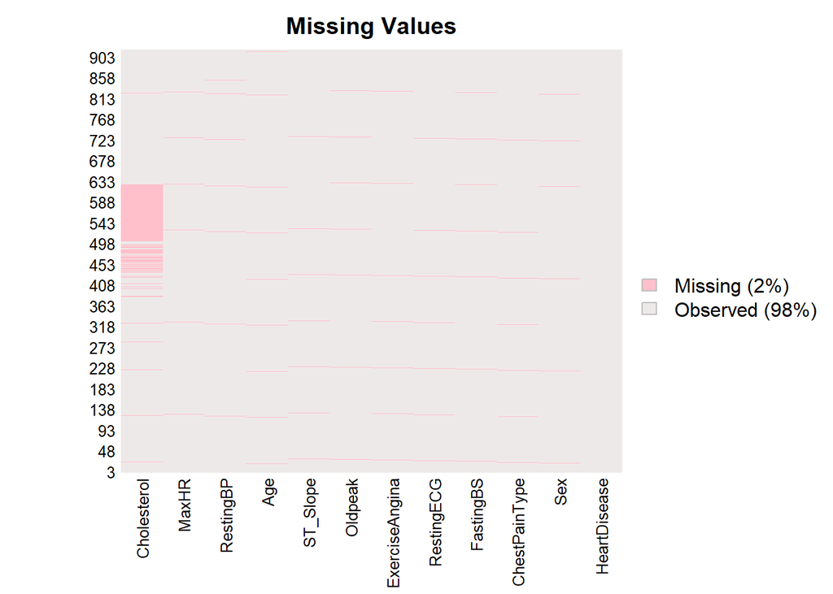

```r
# We see that the variable cholesterol has the majority of the NAs
missmap(heart_data, main = "Missing Values", col = c("pink", "snow2"))
```

Now let’s impute the NAs:

```r
# Replacing the NAs by knn imputation:
preProcess_missingdata <- preProcess(heart_data, method='knnImpute')
data1 <- predict(preProcess_missingdata, newdata = heart_data)

anyNA(data1)
```

```
## [1] TRUE
```

```r
sum(is.na(data1))
```

```
## [1] 54
```

```r
for(i in 1:ncol(data1)){
  if(any(is.na(data1[,i]))){
    cat("Variable ",names(data1)[i]," has NA values\n")
  }
}
```

```
## Variable  Sex  has NA values
## Variable  ChestPainType  has NA values
## Variable  FastingBS  has NA values
## Variable  RestingECG  has NA values
## Variable  ExerciseAngina  has NA values
## Variable  ST_Slope  has NA values
```

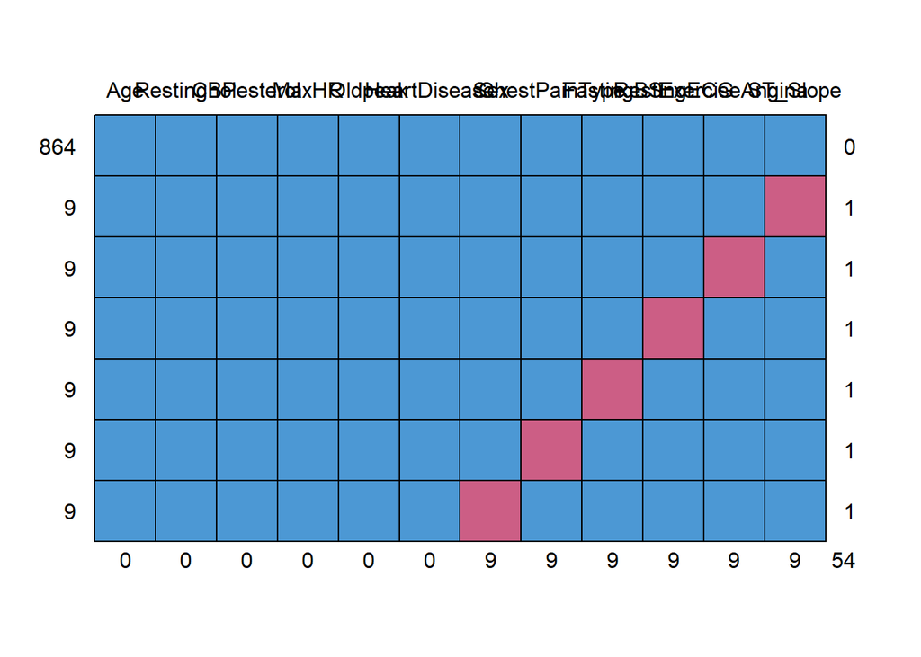

```
##     Age RestingBP Cholesterol MaxHR Oldpeak HeartDisease Sex ChestPainType
## 864   1         1           1     1       1            1   1             1
## 9     1         1           1     1       1            1   1             1
## 9     1         1           1     1       1            1   1             1
## 9     1         1           1     1       1            1   1             1
## 9     1         1           1     1       1            1   1             1
## 9     1         1           1     1       1            1   1             0
## 9     1         1           1     1       1            1   0             1
##       0         0           0     0       0            0   9             9
##     FastingBS RestingECG ExerciseAngina ST_Slope
## 864         1          1              1        1  0
## 9           1          1              1        0  1
## 9           1          1              0        1  1
## 9           1          0              1        1  1
## 9           0          1              1        1  1
## 9           1          1              1        1  1
## 9           1          1              1        1  1
##             9          9              9        9 54
```

```r
# Finally, we need to replace the missing values left.
# To do this we are going to use Multiple Imputation:
md.pattern(data1)
```

```r
vec1 <- c()
for(i in 1:ncol(data1)){
  if(any(is.na(data1[,i]))){
    vec1 <- c(vec1,i)
  }
}


imp=mice(data1[,vec1], method = 'rf')
data_imp=mice::complete(imp)
data <- data1
data$Sex = data_imp$Sex
data$ChestPainType =data_imp$ChestPainType
data$FastingBS = data_imp$FastingBS
data$RestingECG = data_imp$RestingECG
data$ExerciseAngina = data_imp$ExerciseAngina
data$ST_Slope = data_imp$ST_Slope

sum(is.na(data))
```

```
## [1] 0
```

```r
# We don't have any NA in our dataset.
```

Now let’s make some more graphs to have more insights about the data. We will do some graphs involving different variables to better understand the relation between them.

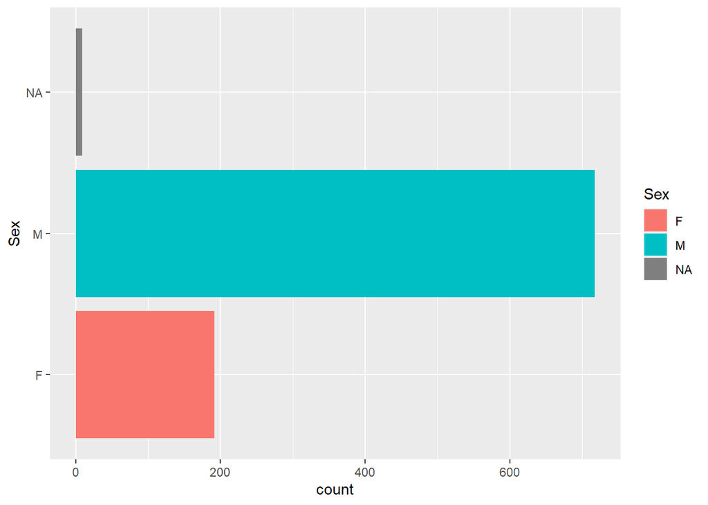

```r
ggplot(heart_data)+aes(Sex, fill = Sex)+geom_bar()+coord_flip()
```

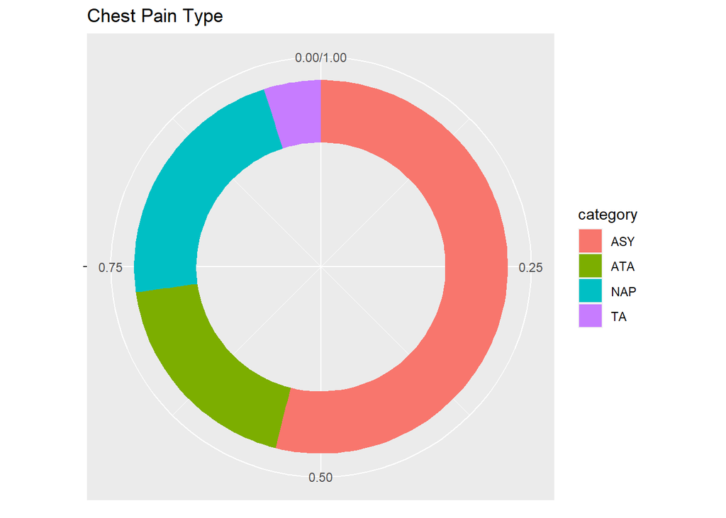

```r
# Let's see the distribution of the ChestPainType variable with a doughnut chart
# Source: https://r-graph-gallery.com/

df_aux<- data.frame(table(heart_data$ChestPainType))
df <- data.frame(
  category=df_aux$Var1,
  count=df_aux$Freq
)
# Compute percentages
df$fraction = df$count / sum(df$count)
# Compute the cumulative percentages (top of each rectangle)
df$ymax = cumsum(df$fraction)
# Compute the bottom of each rectangle
df$ymin = c(0, head(df$ymax, n=-1))
# Make the plot
ggplot(df, aes(ymax=ymax, ymin=ymin, xmax=4, xmin=3, fill=category)) +
  geom_rect() +
  coord_polar(theta="y") + # Try to remove that to understand how the chart is built initially
  xlim("")+ggtitle("Chest Pain Type")
```

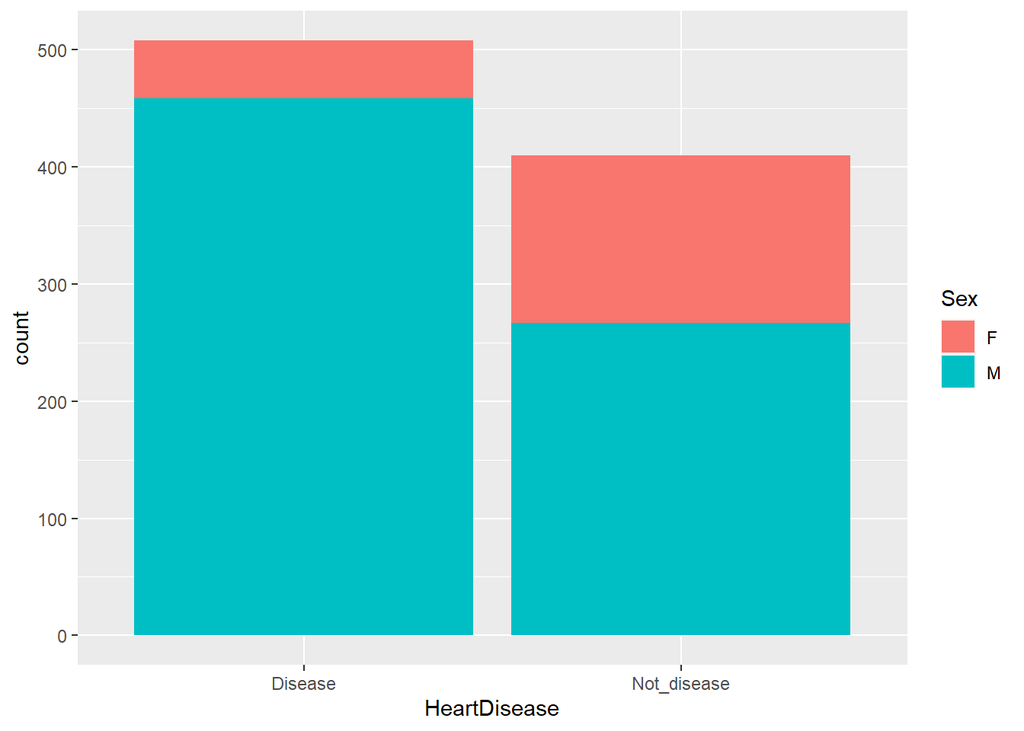

```r
ggplot(data, aes(x=HeartDisease,fill = Sex)) + geom_bar()
```

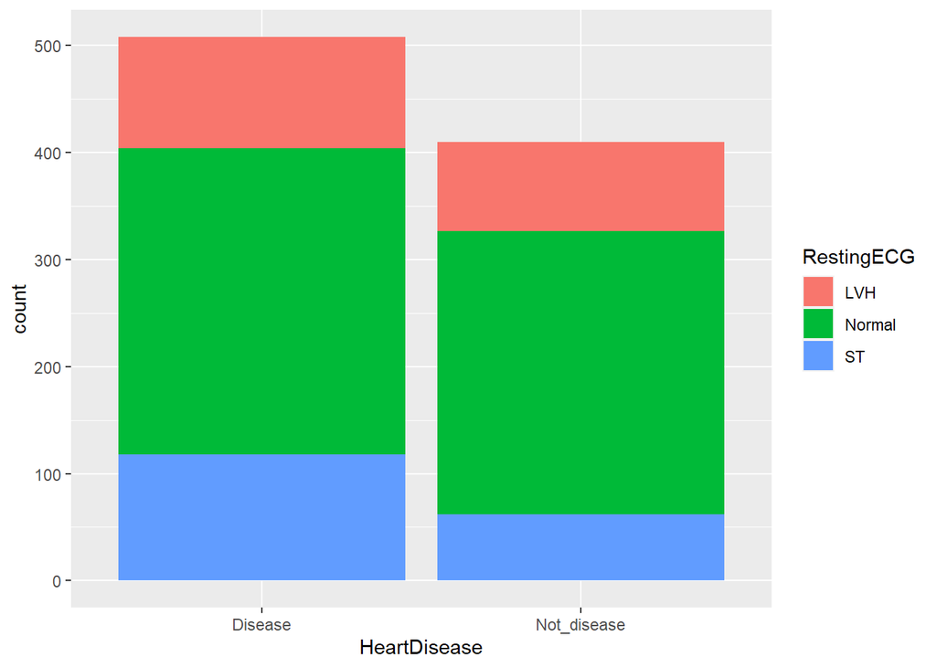

```r
ggplot(data, aes(x=HeartDisease,fill = RestingECG)) + geom_bar()
```

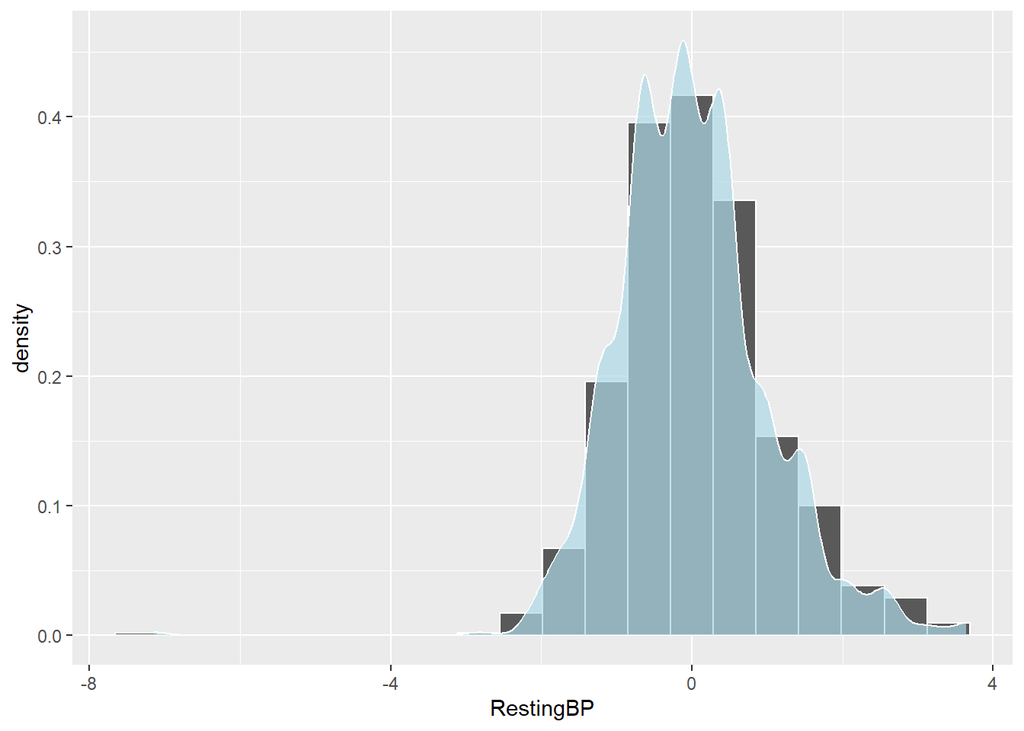

```r
ggplot(data) +aes(x=RestingBP) + geom_histogram(aes(y=..density..),bins=20,color="white") +
  geom_density(color="white",fill="lightblue",alpha=0.7)
```

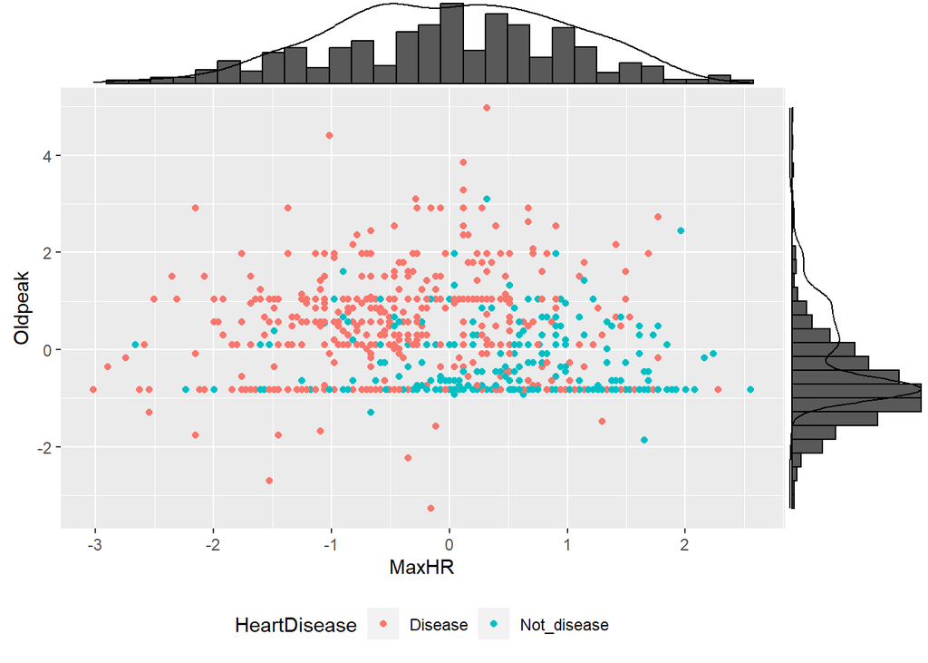

```r
p<- ggplot(data, aes(x=Age, y=Cholesterol, color=HeartDisease)) +
      geom_point() +
      theme(legend.position="bottom")
ggMarginal(p, type="histogram")
# It seems that the level of cholesterol is independent of the age.

p<- ggplot(data, aes(x=MaxHR, y=Oldpeak, color=HeartDisease)) +
      geom_point() +
      theme(legend.position="bottom")
ggMarginal(p, type="density")
```

[output not shown]

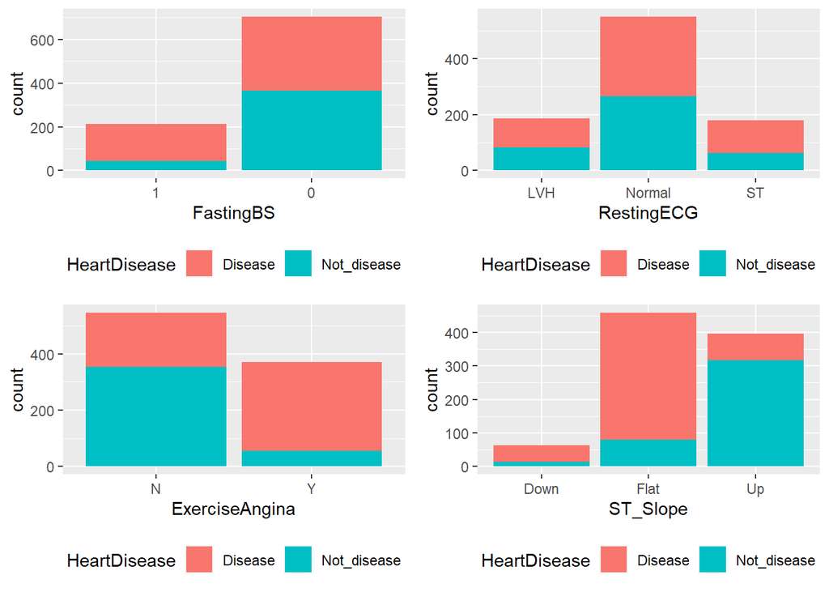

```r
g1 <- ggplot(data,aes(FastingBS, fill=HeartDisease))+geom_bar()+theme(legend.position = 'bottom')
g2 <- ggplot(data,aes(RestingECG, fill=HeartDisease))+geom_bar()+theme(legend.position = 'bottom')
g3 <- ggplot(data,aes(ExerciseAngina, fill=HeartDisease))+geom_bar()+theme(legend.position = 'bottom')
g4 <- ggplot(data,aes(ST_Slope, fill=HeartDisease))+geom_bar()+theme(legend.position = 'bottom')
grid.arrange(arrangeGrob(g1, g2, ncol=2), arrangeGrob(g3, g4, ncol=2), nrow = 2)
```

## CLASIFICATION

The first thing we have to do is to split our data between training and testing set:

```r
split = sample.split(data$HeartDisease, SplitRatio = 0.8)
# With this function we get a boolean vector with the same length as the variable HeartDisease. We will include in the training set the observations in the vector that are TRUE.
training = subset(data, split == TRUE)
testing = subset(data, split == FALSE)
# 80% of the data is now in the training set

# Another option to split the data would be:
# in_train <- createDataPartition(heart_data$HeartDisease, p = 0.8, list = FALSE)  # 80% for training
# training1 <- heart_data[ in_train,]
# testing1 <- heart_data[-in_train,]
```

Is our variable of interest balanced?

```r
table(training$HeartDisease)
```

```
##
##     Disease Not_disease
##         406         328
```

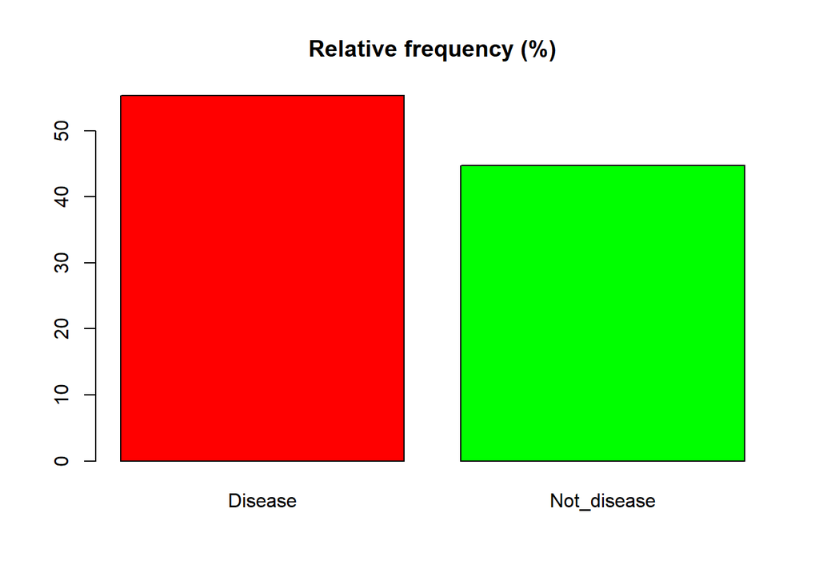

```r
barplot(prop.table(table(training$HeartDisease)) * 100,
        main = "Relative frequency (%)",col = rainbow(3))
```

```r
# Yes, it is pretty balanced
```

### Binary logistic regression

As in logistic regression the predictors can be either continuous or categorical, we can perfectly use all our data to predict whether the person has a Heart Disease or not.

```r
logit.model <- glm(HeartDisease ~ ., family=binomial(link='logit'), data=training)
summary(logit.model)
```

```
##
## Call:
## glm(formula = HeartDisease ~ ., family = binomial(link = "logit"),
##     data = training)
##
## Deviance Residuals:
##     Min       1Q   Median       3Q      Max
## -2.6228  -0.4983  -0.2077   0.4167   2.7243
##
## Coefficients:
##                  Estimate Std. Error z value Pr(>|z|)
## (Intercept)      -0.45736    0.57969  -0.789 0.430132
## Age              -0.10353    0.13494  -0.767 0.442958
## SexM             -1.58973    0.30114  -5.279 1.30e-07 ***
## ChestPainTypeATA  1.96280    0.36244   5.415 6.11e-08 ***
## ChestPainTypeNAP  1.60549    0.28574   5.619 1.92e-08 ***
## ChestPainTypeTA   1.55531    0.45858   3.392 0.000695 ***
## RestingBP         0.02754    0.12250   0.225 0.822134
## Cholesterol      -0.09718    0.12462  -0.780 0.435507
## FastingBS0        1.21529    0.28374   4.283 1.84e-05 ***
## RestingECGNormal  0.11305    0.29195   0.387 0.698588
## RestingECGST      0.02340    0.37403   0.063 0.950126
## MaxHR             0.21724    0.13431   1.617 0.105793
## ExerciseAnginaY  -0.65932    0.26427  -2.495 0.012600 *
## Oldpeak          -0.39395    0.13177  -2.990 0.002792 **
## ST_SlopeFlat     -1.19594    0.46862  -2.552 0.010710 *
## ST_SlopeUp        0.98936    0.48244   2.051 0.040292 *
## ---
## Signif. codes:  0 '***' 0.001 '**' 0.01 '*' 0.05 '.' 0.1 ' ' 1
##
## (Dispersion parameter for binomial family taken to be 1)
##
##     Null deviance: 1009.24  on 733  degrees of freedom
## Residual deviance:  509.66  on 718  degrees of freedom
## AIC: 541.66
##
## Number of Fisher Scoring iterations: 5
```

```r
# With this model, we can compute the posterior probabilities:
# Probability of NOT Disease given the value of the predictors.

probability <- predict(logit.model,newdata=testing, type='response')
head(probability)
```

```
##         3         4         6         7        11        16
## 0.9051275 0.2081046 0.9222037 0.9893963 0.9832167 0.8106535
```

```r
# Person 3 has a posterior probability of 90% (of not having Disease)
# Person 4 has a posterior probability of 20% (of not having Disease),
# this means that we are going to predict this person as Disease.
```

If the posterior probability is higher than 0.5, we consider that the person is healthy, and if it is less it will be predicted as Disease (as the Heart Disease variable is more or less balanced, this will work fine).

```r
prediction <- as.factor(ifelse(probability > 0.5,"Not_disease","Disease"))
head(prediction)
```

```
##           3           4           6           7          11          16
## Not_disease     Disease Not_disease Not_disease Not_disease Not_disease
## Levels: Disease Not_disease
```

```r
# Let's now evaluate the performance of our model:
confusionMatrix(prediction, testing$HeartDisease)
```

```
## Confusion Matrix and Statistics
##
##              Reference
## Prediction    Disease Not_disease
##   Disease          96          13
##   Not_disease       6          69
##
##                Accuracy : 0.8967
##                  95% CI : (0.8434, 0.9367)
##     No Information Rate : 0.5543
##     P-Value [Acc > NIR] : <2e-16
##
##                   Kappa : 0.7892
##
##  Mcnemar's Test P-Value : 0.1687
##
##             Sensitivity : 0.9412
##             Specificity : 0.8415
##          Pos Pred Value : 0.8807
##          Neg Pred Value : 0.9200
##              Prevalence : 0.5543
##          Detection Rate : 0.5217
##    Detection Prevalence : 0.5924
##       Balanced Accuracy : 0.8913
##
##        'Positive' Class : Disease
##
```

## Penalized logistic regression

To avoid overfitting (when we are fitting an over complicated variable to our data, this is, when we have tons of variables), the solution is to penalize. Without any penalty, the goal of our model is just to reduce the error (distance between the model and the observations). Penalized regression adds a term for model complexity to the error that the regression algorithm tries to minimize (MSE, R2…).

We reduce variance at the cost of increment bias.

```r
# Let's do penalized regression, but let's find the best possible one.
# In order to do this, we are going to try with different methods and
# different values of lambda.
ctrl <- trainControl(method = "cv", number = 5,
                     classProbs = TRUE,
                     verboseIter=T)

lrFit <- train(HeartDisease ~ .,
               method = "glmnet",
               tuneGrid = expand.grid(alpha = seq(0, 1, 0.1), lambda = seq(0, .1, 0.01)),
               metric = "Kappa",
               # lrfit is going to select the combination
               # of hyperparameters that maximize the Kappa statistic
               data = training,
               trControl = ctrl)
print(lrFit)
```

```
## glmnet
##
## 734 samples
##  11 predictor
##   2 classes: 'Disease', 'Not_disease'
##
## No pre-processing
## Resampling: Cross-Validated (5 fold)
## Summary of sample sizes: 588, 588, 587, 586, 587
## Resampling results across tuning parameters:
##
##   alpha  lambda  Accuracy   Kappa
##   0.0    0.00    0.8528903  0.7016502
##   0.0    0.01    0.8528903  0.7016502
##   0.0    0.02    0.8528903  0.7016502
##   0.0    0.03    0.8528903  0.7016502
##   0.0    0.04    0.8515297  0.6986071
##   0.0    0.05    0.8474294  0.6904001
##   0.0    0.06    0.8474201  0.6901406
##   0.0    0.07    0.8501505  0.6955464
##   0.0    0.08    0.8501505  0.6955464
##   0.0    0.09    0.8501505  0.6955464
##   0.0    0.10    0.8501505  0.6955464
##   0.1    0.00    0.8474109  0.6909490
##   0.1    0.01    0.8487622  0.6935828
##   0.1    0.02    0.8515205  0.6989734
##   0.1    0.03    0.8501599  0.6961510
##   0.1    0.04    0.8515390  0.6988809
##   0.1    0.05    0.8515203  0.6986369
##   0.1    0.06    0.8542416  0.7039363
##   0.1    0.07    0.8542416  0.7039363
##   0.1    0.08    0.8515112  0.6982356
##   0.1    0.09    0.8515112  0.6982356
##   0.1    0.10    0.8501598  0.6953826
##   0.2    0.00    0.8460595  0.6883230
##   0.2    0.01    0.8515020  0.6991406
##   0.2    0.02    0.8501599  0.6963269
##   0.2    0.03    0.8515390  0.6988809
##   0.2    0.04    0.8528810  0.7014766
##   0.2    0.05    0.8542416  0.7039095
```

[output cut: 81 more lines]

```
##   0.9    0.10    0.8092223  0.6130867
##   1.0    0.00    0.8433568  0.6826441
##   1.0    0.01    0.8460689  0.6879411
##   1.0    0.02    0.8515297  0.6983889
##   1.0    0.03    0.8488179  0.6928197
##   1.0    0.04    0.8419782  0.6792442
##   1.0    0.05    0.8296867  0.6546801
##   1.0    0.06    0.8187464  0.6316039
##   1.0    0.07    0.8146740  0.6232124
##   1.0    0.08    0.8078618  0.6099721
##   1.0    0.09    0.8051314  0.6054072
##   1.0    0.10    0.8037892  0.6029484
##
## Kappa was used to select the optimal model using the largest value.
## The final values used for the model were alpha = 0.7 and lambda = 0.03.
```

```r
lrPred = predict(lrFit, testing)
```

The results are:

```r
# The best hyperparameters are:
lrFit$results$alpha[which.max(lrFit$results$Kappa)]
```

```
## [1] 0.7
```

```r
lrFit$results$lambda[which.max(lrFit$results$Kappa)]
```

```
## [1] 0.03
```

```r
# Which is the same as:
lrFit$bestTune
```

|  | alpha | lambda |
| --- | --- | --- |
| 81 | 0.7 | 0.03 |

```r
# The best accuracy is given by:
lrFit$results$alpha[which.max(lrFit$results$Accuracy)]
```

```
## [1] 0.7
```

```r
lrFit$results$lambda[which.max(lrFit$results$Accuracy)]
```

```
## [1] 0.03
```

```r
# The best accuracy is also achieved by the hyperparameters with higher kappa.

confusionMatrix(lrPred, testing$HeartDisease)
```

```
## Confusion Matrix and Statistics
##
##              Reference
## Prediction    Disease Not_disease
##   Disease          97          14
##   Not_disease       5          68
##
##                Accuracy : 0.8967
##                  95% CI : (0.8434, 0.9367)
##     No Information Rate : 0.5543
##     P-Value [Acc > NIR] : < 2e-16
##
##                   Kappa : 0.7887
##
##  Mcnemar's Test P-Value : 0.06646
##
##             Sensitivity : 0.9510
##             Specificity : 0.8293
##          Pos Pred Value : 0.8739
##          Neg Pred Value : 0.9315
##              Prevalence : 0.5543
##          Detection Rate : 0.5272
##    Detection Prevalence : 0.6033
##       Balanced Accuracy : 0.8901
##
##        'Positive' Class : Disease
##
```

```r
# Kappa 0.78 creo que está bastnate bien
# The results we get are practically the same as what we got with
# non-penalized logistic regression.
```

**ROC curve** The ROC curve compares false positives rates with true positives. ROC curve shows true positives vs false positives in relation with different thresholds.

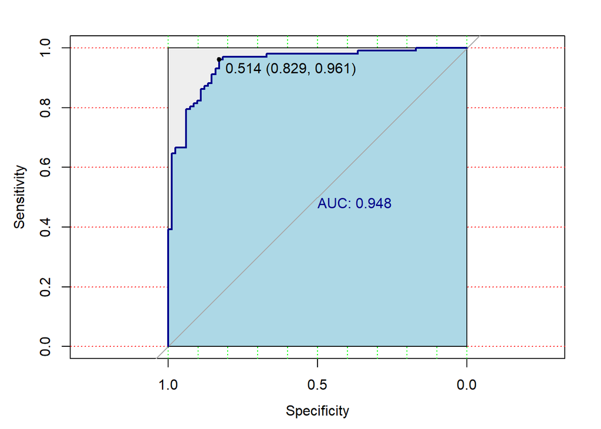

```r
# We are inerested in minimizing false negatives
lrProb = predict(lrFit, testing, type="prob")

plot.roc(testing$HeartDisease, lrProb[,2],col="darkblue", print.auc = TRUE,  auc.polygon=TRUE, grid=c(0.1, 0.2),
         grid.col=c("green", "red"), max.auc.polygon=TRUE,
         auc.polygon.col="lightblue", print.thres=TRUE,  levels=c("Not_disease", "Disease"))
```

The recommended threshold is 0.514 ,which is very near to the 0.5 that we previously chose (this is because our classes are balanced). This is the threshold with the best balance between sensitivity and specificity (the nearest to the top left corner of the chart) Our area under the curve is really really good: 0.95

What We have found the threshold with the higher sentisitivity-especificity ratio. But for us, the sensitivity is more important than the specifity (remember that the higher sensitivity, the lower specificity), since it is consider that it is worse predicting as healthy someone with a disease than having a false positive (predicting as ill someone healthy).

*Which is the best model?* The importance of the specificity depends on the disease. For a person with cancer who need an urgent treatment, sensivility is more important. However, in a terminal disease specificity is more relevatn, since starting the treatment in a healthy person could be worse than not treating someone ill.

But in general, a medical diagnose is considergood if the excellent if it has a sensitivity >95% and a specificity higher than 80%. Therefore, we will choose the model with the higher specificity among those with a sensitivity >95%.

Fuentes: https://lafisioterapia.net/sensibilidad-especificidad/ https://www.sergas.es/Saude-publica/Documents/1932/6-Ayuda%20Pruebas%20diagnsticas.pdf https://docs.bvsalud.org/biblioref/2018/05/883697/importancia-calculo-sensibilidad-y-especifidad.pdf

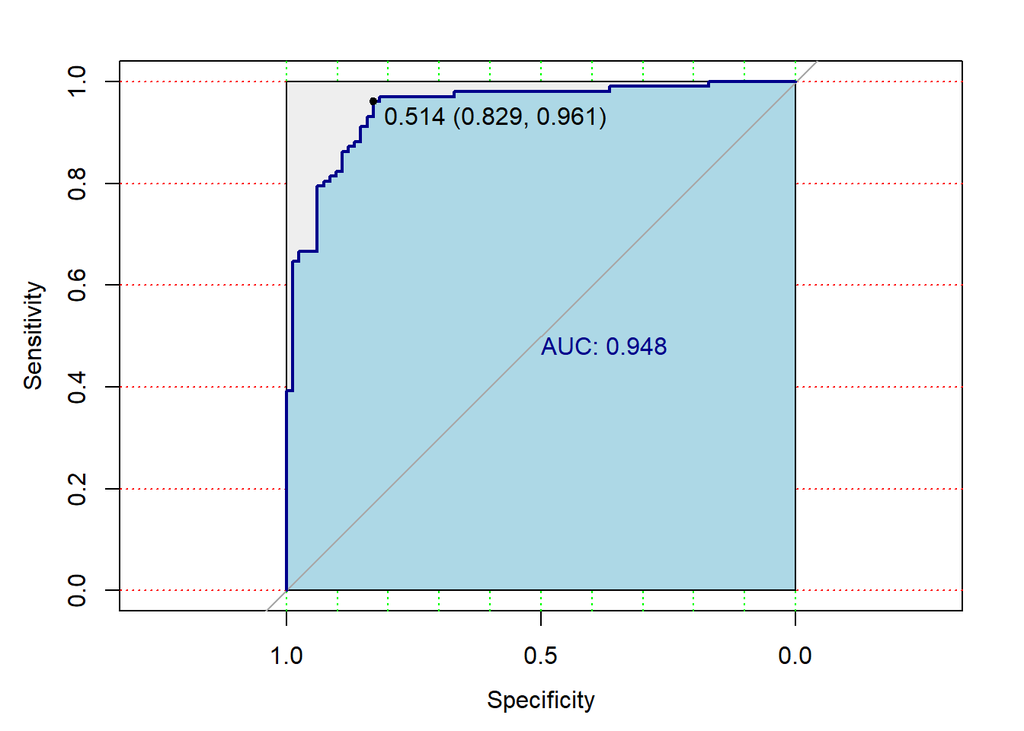

```r
# In order to have a high sensitivity and still have a good specificity, we have to look in the table of the values of the toc curve.
a <- plot.roc(testing$HeartDisease, lrProb[,2],col="darkblue",
              print.auc = TRUE,  auc.polygon=TRUE, grid=c(0.1, 0.2),
              grid.col=c("green", "red"), max.auc.polygon=TRUE,
              auc.polygon.col="lightblue", print.thres=TRUE,
              levels=c("Not_disease", "Disease"))
```

```r
dfprueba <- data.frame(a$sensitivities, a$specificities, a$thresholds)


which.max(dfprueba$a.specificities[dfprueba$a.sensitivities>=0.95])
```

```
## [1] 73
```

```r
# threshold 73
best_threshold<- dfprueba$a.thresholds[which.max(dfprueba$a.specificities[dfprueba$a.sensitivities>=0.95])]
best_threshold
```

```
## [1] 0.5140552
```

```r
# We see that it is the same as before. So this means that this is not onnly the threshold with the best sensitivity-specificity relation, but also the one with a higher specificity among those with >95% specificity.
```

Let’s now use this threshold to predict

```r
threshold = best_threshold
lrProb = predict(lrFit, testing, type="prob")
lrPred = rep("Disease", nrow(testing))
lrPred[which(lrProb[,2] > threshold)] = "Not_disease"
confusionMatrix(factor(lrPred), testing$HeartDisease)
```

```
## Confusion Matrix and Statistics
##
##              Reference
## Prediction    Disease Not_disease
##   Disease          98          14
##   Not_disease       4          68
##
##                Accuracy : 0.9022
##                  95% CI : (0.8498, 0.941)
##     No Information Rate : 0.5543
##     P-Value [Acc > NIR] : < 2e-16
##
##                   Kappa : 0.7996
##
##  Mcnemar's Test P-Value : 0.03389
##
##             Sensitivity : 0.9608
##             Specificity : 0.8293
##          Pos Pred Value : 0.8750
##          Neg Pred Value : 0.9444
##              Prevalence : 0.5543
##          Detection Rate : 0.5326
##    Detection Prevalence : 0.6087
##       Balanced Accuracy : 0.8950
##
##        'Positive' Class : Disease
##
```

```r
# Accuracy : 0.9022
# Kappa : 0.7996
# Sensitivity : 0.9608
# Specificity : 0.8293

# As the threshold is alsmost the same as before, the results are very
# similar (and quite good in my opinion)
```

## Decision trees

```r
# Hyper-parameters
control = rpart.control(minsplit = 30, maxdepth = 10, cp=0.01)
# minsplit: minimum number of observations in a node before before a split
# maxdepth: maximum depth of any node of the final tree
# cp: degree of complexity, the smaller the more branches


model = HeartDisease ~.
dtFit <- rpart(model, data=training, method = "class", control = control)
summary(dtFit)
```

```
## Call:
## rpart(formula = model, data = training, method = "class", control = control)
##   n= 734
##
##           CP nsplit rel error    xerror       xstd
## 1 0.56402439      0 1.0000000 1.0000000 0.04106559
## 2 0.03506098      1 0.4359756 0.4359756 0.03271447
## 3 0.01067073      3 0.3658537 0.4054878 0.03181568
## 4 0.01000000      6 0.3292683 0.4268293 0.03245154
##
## Variable importance
##       ST_Slope  ChestPainType        Oldpeak ExerciseAngina          MaxHR
##             31             19             16             13             13
##            Age      RestingBP      FastingBS     RestingECG
##              6              1              1              1
##
## Node number 1: 734 observations,    complexity param=0.5640244
##   predicted class=Disease      expected loss=0.4468665  P(node) =1
##     class counts:   406   328
##    probabilities: 0.553 0.447
##   left son=2 (407 obs) right son=3 (327 obs)
##   Primary splits:
##       ST_Slope       splits as  LLR, improve=133.16160, (0 missing)
##       ChestPainType  splits as  LRRR, improve= 98.51773, (0 missing)
##       ExerciseAngina splits as  RL, improve= 84.27617, (0 missing)
##       Oldpeak        < 0.05774215  to the right, improve= 60.82734, (0 missing)
##       MaxHR          < -0.1736548  to the left,  improve= 52.28552, (0 missing)
##   Surrogate splits:
##       Oldpeak        < -0.5041235  to the right, agree=0.744, adj=0.425, (0 split)
##       ExerciseAngina splits as  RL, agree=0.710, adj=0.349, (0 split)
##       MaxHR          < 0.4537655   to the left,  agree=0.691, adj=0.306, (0 split)
##       ChestPainType  splits as  LRRL, agree=0.688, adj=0.300, (0 split)
##       Age            < -0.1105291  to the right, agree=0.624, adj=0.156, (0 split)
##
## Node number 2: 407 observations,    complexity param=0.01067073
##   predicted class=Disease      expected loss=0.1769042  P(node) =0.5544959
##     class counts:   335    72
##    probabilities: 0.823 0.177
##   left son=4 (289 obs) right son=5 (118 obs)
##   Primary splits:
```

[output cut: 99 more lines]

```
##
## Node number 13: 70 observations
##   predicted class=Not_disease  expected loss=0.3142857  P(node) =0.09536785
##     class counts:    22    48
##    probabilities: 0.314 0.686
##
## Node number 22: 29 observations
##   predicted class=Disease      expected loss=0.4137931  P(node) =0.03950954
##     class counts:    17    12
##    probabilities: 0.586 0.414
##
## Node number 23: 38 observations
##   predicted class=Not_disease  expected loss=0.3421053  P(node) =0.05177112
##     class counts:    13    25
##    probabilities: 0.342 0.658
```

Let’s plot it to see it clearer:

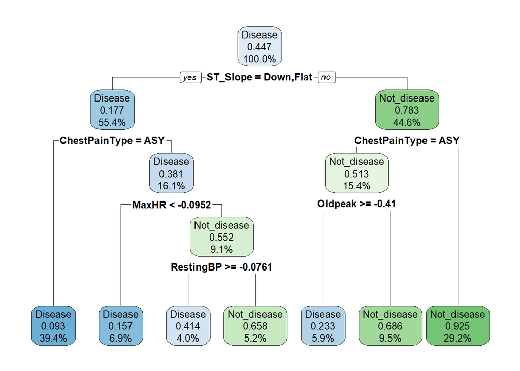

```r
library(rpart.plot)
rpart.plot(dtFit, digits=3)
```

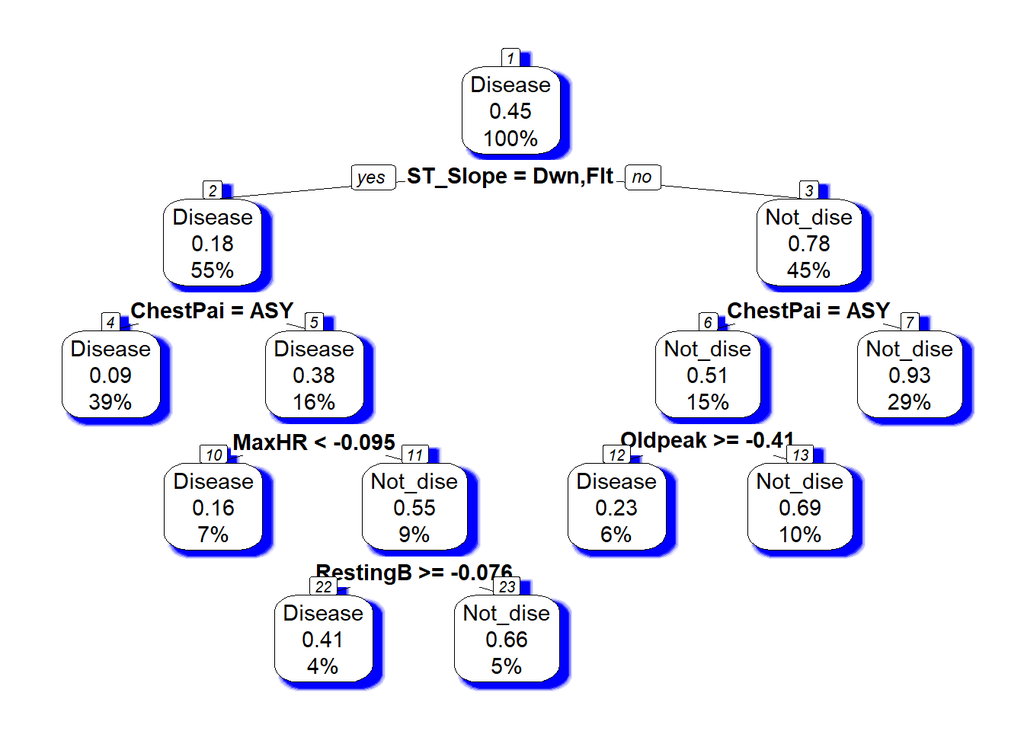

```r
# We can change some things to make the plot more visual:
prp(dtFit,type=2,extra=106,nn=TRUE,shadow.col="blue",
    digits=2, roundint=FALSE)
```

The decision tree can be interpreted as if we were meaking yes/no questions and classificating the patients depending on their answers. In this case, the first question would be if the patient has the slope of the peaks exercise ST segment (variable ST_Slope) either down or flat. If the answers was yes (ST_Slope is Down or Flat) we would predict that the person has a disease. The successives divisions of the tree are more “questions” in order to predict better. Each branch of the tree defines a group of person that would be classify in a certain way. For instance, in this case people with ST_Slope = Up and ChestPainType different from asympotomatic (ASY) will be predicted as healthy.

Now let’s see which are the variables that contribute the most to the decision tree (in general, the variables nearer to the root are the more important)

```r
# Variable importance:
dtFit$variable.importance
```

```
##       ST_Slope  ChestPainType        Oldpeak ExerciseAngina          MaxHR
##     133.161592      79.374240      69.765055      55.823086      54.527726
##            Age      RestingBP      FastingBS     RestingECG    Cholesterol
##      25.865346       3.380247       2.607552       2.485258       1.239391
```

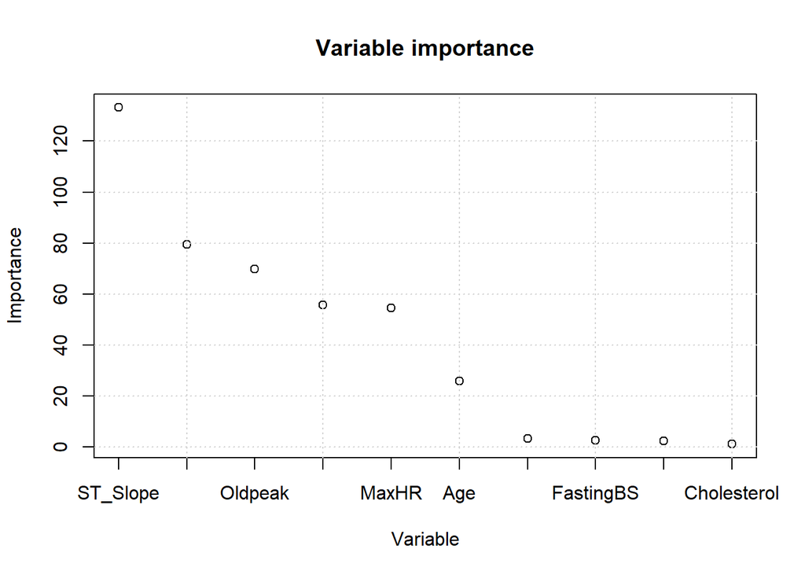

```r
plot(dtFit$variable.importance,
       xaxt="n",
       xlab="Variable",ylab="Importance")
title("Variable importance")
axis(side=1,
     at=seq(1, length(dtFit$variable.importance), by=1),
     labels = names(dtFit$variable.importance),)
grid()
```

```r
# The variables nearer to the main root of the tree are usually the most
# important ones, as in this case. The three most important variables
# for the decision tree are ST_Slope, ChestPainType and OldPeak.
```

Let’s predict using the decision tree:

```r
dtPred <- predict(dtFit, testing, type = "class")

dtProb <- predict(dtFit, testing, type = "prob")
threshold = best_threshold
dtPred = rep("Disease", nrow(testing))
dtPred[which(dtProb[,2] > threshold)] = "Not_disease"
CM = confusionMatrix(factor(dtPred), testing$HeartDisease)$table
CM
```

```
##              Reference
## Prediction    Disease Not_disease
##   Disease          91          16
##   Not_disease      11          66
```

```r
sum(diag(CM))/sum(CM) # Accuracy
```

```
## [1] 0.8532609
```

```r
CM[1,1]/sum(CM[1,]) #Precision
```

```
## [1] 0.8504673
```

```r
CM[2,2]/sum(CM[,2]) # Specificity
```

```
## [1] 0.804878
```

```r
CM[1,1]/sum(CM[,1]) # Sensitivity
```

```
## [1] 0.8921569
```

Although this is not a very complicated model the results are not bad, yet it can be improved by using most sophisticated methods, which is what we are going to do later with random forest. Before that, let’s do another decision tree using caret:

```r
caret.fit <- train(model,
                   data = training,
                   method = "rpart", metric = "Accuracy",
                   control=rpart.control(minsplit = 40, maxdepth = 12),
                   trControl = trainControl(method = "repeatedcv",
                                            number = 5),
                   tuneLength=10)
caret.fit
```

```
## CART
##
## 734 samples
##  11 predictor
##   2 classes: 'Disease', 'Not_disease'
##
## No pre-processing
## Resampling: Cross-Validated (5 fold, repeated 1 times)
## Summary of sample sizes: 587, 586, 587, 588, 588
## Resampling results across tuning parameters:
##
##   cp          Accuracy   Kappa
##   0.00000000  0.7968839  0.5881903
##   0.06266938  0.8051402  0.6054217
##   0.12533875  0.8051402  0.6054217
##   0.18800813  0.8051402  0.6054217
##   0.25067751  0.8051402  0.6054217
##   0.31334688  0.8051402  0.6054217
##   0.37601626  0.8051402  0.6054217
##   0.43868564  0.8051402  0.6054217
##   0.50135501  0.8051402  0.6054217
##   0.56402439  0.6387717  0.2115296
##
## Accuracy was used to select the optimal model using the largest value.
## The final value used for the model was cp = 0.501355.
```

```r
caret.fit$finalModel$variable.importance
```

```
##       ST_SlopeUp     ST_SlopeFlat          Oldpeak  ExerciseAnginaY
##        133.16159        112.39327         56.60386         46.42331
##            MaxHR ChestPainTypeATA
##         40.72220         35.42831
```

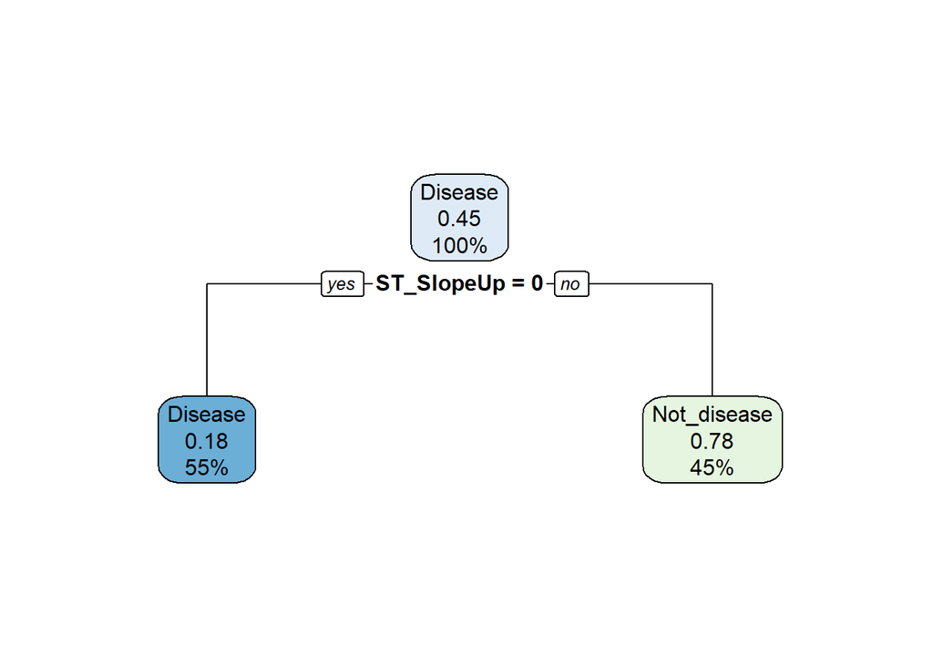

```r
# It seems that the variable ST_Slope is by far the most important to classify

# Plot
rpart.plot(caret.fit$finalModel)
```

This is really curious, it is classifying just taking into account the ST_Slope variable. If the patient has ST_Slope = Up it is classify as “no disease”, but if it has Down or Flat it is classify as “Disease”. It is a very simple classification, but let’s see how are the results.

Is it true that the majority of observations with ‘Up’ in the variable ST_Slope are ‘Not_disease’?

```r
sum(data$HeartDisease[data$ST_Slope=="Up"] == "Not_disease")/sum(data$ST_Slope=="Up")
```

```
## [1] 0.7979798
```

```r
sum(data$HeartDisease[data$ST_Slope=="Up"] == "Not_disease")/sum(data$HeartDisease=="Not_disease")
```

```
## [1] 0.7707317
```

```r
# 79.8% of people with ST_Slope=="Up" are also healthy ('not disease') and
# 77% of healthy people have ST_Slope == "Up".

# Wow, this is something that we did not notice until now but it is extremely
# relevant for our study. We could make a decent model just using ST_Slope variable as a predictor
```

Prediction using this model:

```r
dtProb <- predict(caret.fit, testing, type = "prob")
threshold = best_threshold
dtPred = rep("Disease", nrow(testing))
dtPred[which(dtProb[,2] > threshold)] = "Not_disease"
CM = confusionMatrix(factor(dtPred), testing$HeartDisease)$table
CM
```

```
##              Reference
## Prediction    Disease Not_disease
##   Disease          93          22
##   Not_disease       9          60
```

```r
sum(diag(CM))/sum(CM) # Accuracy
```

```
## [1] 0.8315217
```

```r
CM[1,1]/sum(CM[1,]) #Precision
```

```
## [1] 0.8086957
```

```r
CM[2,2]/sum(CM[,2]) # Specificity
```

```
## [1] 0.7317073
```

```r
CM[1,1]/sum(CM[,1]) # Sensitivity
```

```
## [1] 0.9117647
```

```r
# The results are similar as in the previous case. Sensitivity is a bit
# higher at the cost of losing specificity and a bit of accuracy.
```